# MachineLearning-Coursera

Ryan Greenway

December 17, 2015

# Executive Summary

An additional note: this algorithm was further tested on a small data set of 20 rows and classified all 20 correctly.

Citation: Velloso, E.; Bulling, A.; Gellersen, H.; Ugulino, W.; Fuks, H. Qualitative Activity Recognition of Weight Lifting Exercises. Proceedings of 4th International Conference in Cooperation with SIGCHI (Augmented Human ’13) . Stuttgart, Germany: ACM SIGCHI, 2013.

Read more: http://groupware.les.inf.puc-rio.br/har#ixzz3ubijLD6V

# Step 1: Load the Data and prep for analysis

We’ll load both the training and test data sets but only manipulate the training data. Test data will be held out for the submission (my algorithm performed 20 out of 20 correct in that assignment).

```r
  ## Libraries
  library(ggplot2)
  library(caret)
  library(randomForest)

  setwd("C:/Users/Ramos/Documents/R/MachineLearning") #set working directory

  ## Download Training and Test (hold-out) Data Sets
    #urlTrain <- "https://d396qusza40orc.cloudfront.net/predmachlearn/pml-training.csv"
    #urlTest <- "https://d396qusza40orc.cloudfront.net/predmachlearn/pml-testing.csv"
    urlTrain <- "pml-training.csv" ## Moved to local drive for speed
    urlTest <- "pml-testing.csv"   ## Moved to local drive for speed
  ## Read data into R dataframe
    dataTrain <- read.table(urlTrain, sep=",",header=TRUE,as.is=T)
    dataTest <- read.table(urlTest, sep=",",header=TRUE,as.is=T)

  ## Preprocess data in preparation for Random Forest ML
    #head(dataTrain) #Notice that the first 6 columns aren't useful (time, names, etc.)
    dataTrain <- dataTrain[,8:160] #remove first 6 columns
    dataTrain[, 1:152] <- sapply(dataTrain[, 1:152], as.numeric) #convert to numeric
    dataTrain[,153] <- as.factor(dataTrain[,153]) #make 'classe' a factor
    dataTrain<-dataTrain[,colSums(is.na(dataTrain)) == 0] #remove all columns with 'NA'
```

# Step 2: Split data into training and test for cross-validation

We need to hold out data for validating our model after it’s built. This will split the ‘training’ dataset into a 60% training and 40% test sets.

```r
  ## Set random number seed for repeatability
    set.seed(32323)

  ## Split Training set into training/test for cross-validation; Random Sampling
    inTrain <- createDataPartition(y=dataTrain$classe,p=.6,list=FALSE)
    training <- dataTrain[inTrain,]
    testing <- dataTrain[-inTrain,]
```

# Step 3: Exploratory Data Analysis

We’ll make a few plots of several variables and also look into the remaining variables; only on the training subset.

```r
  summary(training)
```

[figure not shown]

From these plots you can see groupings of the various class categories (different colors on the graphs). We will look for these variables in the final model.

# Step 4: Apply Random Forest in Model Creation

I’m using the RandomForest package and limiting to 500 trees in our machine learning. We are using only 500 trees due to the width of our training data – 52 variables. We’ll also look at the most important variables in the results.

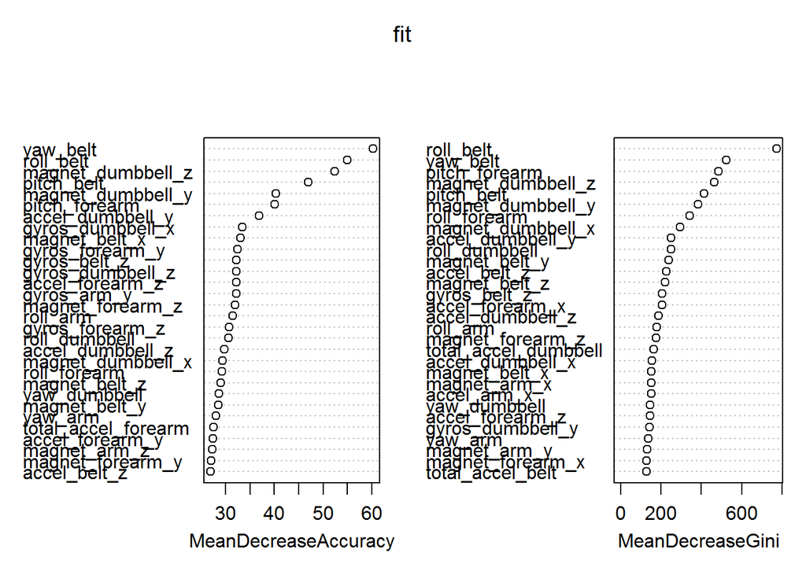

```r
  ## Modeling using Random Forests; Also selects features
    fit <- randomForest(classe ~ ., data=training, importance=TRUE, ntree=500)
    varImpPlot(fit) # List important variables
```

# Step 5: Evaluate the Model

```r
    print(fit)
```

```
##
## Call:
##  randomForest(formula = classe ~ ., data = training, importance = TRUE,      ntree = 500)
##                Type of random forest: classification
##                      Number of trees: 500
## No. of variables tried at each split: 7
##
##         OOB estimate of  error rate: 0.67%
## Confusion matrix:
##      A    B    C    D    E class.error
## A 3344    2    1    0    1 0.001194743
## B   12 2256   11    0    0 0.010092146
## C    0   13 2038    3    0 0.007789679
## D    0    0   31 1898    1 0.016580311
## E    0    0    1    3 2161 0.001847575
```

```r
    predTest <- predict(fit,testing)
    table(predTest,testing$classe)
```

```
##
## predTest    A    B    C    D    E
##        A 2230   12    0    0    0
##        B    2 1504   14    0    0
##        C    0    2 1353   13    5
##        D    0    0    0 1273    4
##        E    0    0    1    0 1433
```